# Hotel Booking Data Analysis — Jupyter Notebook Overview

**This Jupyter Notebook explores a rich Hotel Booking Demand dataset, uncovering patterns behind booking behaviors, cancellations, customer types, and pricing trends. With a wide range of features—from arrival details to special requests—this dataset provides a great opportunity to practice data cleaning, visualization, and predictive insights.**

## Table: Dataset Description — Hotel Booking Features

| **Column / Feature** | **Description** |
| --- | --- |
| **hotel** | Type of hotel (City Hotel / Resort Hotel) |
| **is_canceled** | Indicates whether the booking was cancelled |
| **lead_time** | Number of days between booking date and arrival |
| **arrival_date_year / month / week_number / day_of_month** | Detailed components of the guest’s arrival date |
| **stays_in_weekend_nights / stays_in_week_nights** | Number of weekend and weekday nights stayed |
| **adults, children, babies** | Number of guests in each category |
| **meal** | Selected meal type |
| **country** | Country of origin of the guest |
| **market_segment & distribution_channel** | Booking source and channel used |
| **is_repeated_guest** | Indicates if the guest has booked before |
| **previous_cancellations / previous_bookings_not_canceled** | Guest's past booking and cancellation behavior |
| **reserved_room_type / assigned_room_type** | Room type initially reserved vs. type assigned at check-in |
| **booking_changes** | Total modifications made to the booking |
| **deposit_type** | Whether any deposit was required |
| **agent & company** | IDs of the booking agent or company |
| **days_in_waiting_list** | Number of days the booking was on the waiting list |
| **customer_type** | Type of customer (e.g., transient, group, etc.) |
| **adr** | Average Daily Rate (price per room per night) |
| **total_of_special_requests** | Number of special requests made by the guest |
| **reservation_status & reservation_status_date** | Final booking status and the date of that status |

## Data Analysis Lifecycle

[output not shown]

## S-1 : Understaning Use Case

### Define the Bussiness Problem :

```
 o. Perform descriptive Analysis
 o. Where do the guests come from?
 o. Is any difference between assigned and reservedd room type or not?
 o. 6(a -  Which Market segments has highest booking ?
 o. Analysing Avg.price per night (AOR) of various room-types for all the market segment .
 o. Total guest Arrival on each day ?
```

## S-2 : Extract Data :

```
Collect or import the required dataset from sources such as CSV files, databases, APIs,or other data repositories.
```

```python
# import required Library to perform All step
# Data cleaning -  numpy , pandas most common Library to  used to data extraction ,data preprocessing(Data cleaning)
import numpy as np                   # import numpy and aliasing as np
import pandas as pd                  #import pandas and aliasing as pd
# Dta visualization -  matplotlib , seaborn are most common Library to use data visualization in static format
import matplotlib.pyplot as plt      #import matplotlib and aliasing as plt
import seaborn as sns                #import seaborn and Aliasing as sns
# INteractive visualization -  For Interactive Visualization most common libarary plotly
import plotly.express as px      # import plotly   and aliasing as px
```

Note - I Use csv file which I also added in github repository

```python
# Read data and store in df variable
df = pd.read_csv('hotel_bookings (1).csv')
```

## S3: Data Cleaning: Data preparation for Data Analysis

```python
# show only first five row
df.head()
```

|  | hotel | is_canceled | lead_time | arrival_date_year | arrival_date_month | arrival_date_week_number | arrival_date_day_of_month | stays_in_weekend_nights | stays_in_week_nights | adults | ... | deposit_type | agent | company | days_in_waiting_list | customer_type | adr | required_car_parking_spaces | total_of_special_requests | reservation_status | reservation_status_date |
| --- | --- | --- | --- | --- | --- | --- | --- | --- | --- | --- | --- | --- | --- | --- | --- | --- | --- | --- | --- | --- | --- |
| 0 | Resort Hotel | 0 | 342 | 2015 | July | 27 | 1 | 0 | 0 | 2 | ... | No Deposit | NaN | NaN | 0 | Transient | 0.0 | 0 | 0 | Check-Out | 7/1/2015 |
| 1 | Resort Hotel | 0 | 737 | 2015 | July | 27 | 1 | 0 | 0 | 2 | ... | No Deposit | NaN | NaN | 0 | Transient | 0.0 | 0 | 0 | Check-Out | 7/1/2015 |
| 2 | Resort Hotel | 0 | 7 | 2015 | July | 27 | 1 | 0 | 1 | 1 | ... | No Deposit | NaN | NaN | 0 | Transient | 75.0 | 0 | 0 | Check-Out | 7/2/2015 |
| 3 | Resort Hotel | 0 | 13 | 2015 | July | 27 | 1 | 0 | 1 | 1 | ... | No Deposit | 304.0 | NaN | 0 | Transient | 75.0 | 0 | 0 | Check-Out | 7/2/2015 |
| 4 | Resort Hotel | 0 | 14 | 2015 | July | 27 | 1 | 0 | 2 | 2 | ... | No Deposit | 240.0 | NaN | 0 | Transient | 98.0 | 0 | 1 | Check-Out | 7/3/2015 |

5 rows × 32 columns

```python
# show total row and column of data
print(f'Total rows of Dataset     :  {df.shape[0]}')
print(f'Total columns of Dataset  :  {df.shape[1]}')
```

```
Total rows of Dataset     :  119390
Total columns of Dataset  :  32
```

```python
# Show the name of columns of dataset
df.columns
```

```
Index(['hotel', 'is_canceled', 'lead_time', 'arrival_date_year',
       'arrival_date_month', 'arrival_date_week_number',
       'arrival_date_day_of_month', 'stays_in_weekend_nights',
       'stays_in_week_nights', 'adults', 'children', 'babies', 'meal',
       'country', 'market_segment', 'distribution_channel',
       'is_repeated_guest', 'previous_cancellations',
       'previous_bookings_not_canceled', 'reserved_room_type',
       'assigned_room_type', 'booking_changes', 'deposit_type', 'agent',
       'company', 'days_in_waiting_list', 'customer_type', 'adr',
       'required_car_parking_spaces', 'total_of_special_requests',
       'reservation_status', 'reservation_status_date'],
      dtype='object')
```

```python
# let,s check the unwanted entries -  if (babies,adults,children are 0 , HOw booking Possible
Unwanted_entry= (df['adults']==0) & (df['children']==0) & (df['babies']==0)
```

Note - if adult,children,babies = 0 , That's mean no one come here.

```python
# Total number of  Unwanted_entry
print(f'Total number of  Unwanted_entry: {df[Unwanted_entry].shape[0]}')
```

```
Total number of  Unwanted_entry: 180
```

```python
# Total number of  rows except unwanted data
print(f'Total number of  _entry: {df[~Unwanted_entry].shape[0]}')
```

```
Total number of  _entry: 119210
```

```python
df = df[~Unwanted_entry] #  (~) it means  Exclude
```

Note - len_new_data after remove unwanted_data = len_of_old_data - len_of_unwanted_data = 119390 - 180 = 119210

```python
# chaeck  duplicated  rows
print(f'Total no of duplicate record : {df.duplicated().sum()}')
```

```
Total no of duplicate record : 31980
```

```python
df = df.drop_duplicates()
```

```python
df.shape
```

```
(87230, 32)
```

```python
df.duplicated().sum()
```

```
np.int64(0)
```

## Define the Bussiness Problem

### performing a descriptive Analysis

```python
df.describe()
```

|  | is_canceled | lead_time | arrival_date_year | arrival_date_week_number | arrival_date_day_of_month | stays_in_weekend_nights | stays_in_week_nights | adults | children | babies | is_repeated_guest | previous_cancellations | previous_bookings_not_canceled | booking_changes | agent | company | days_in_waiting_list | adr | required_car_parking_spaces | total_of_special_requests |
| --- | --- | --- | --- | --- | --- | --- | --- | --- | --- | --- | --- | --- | --- | --- | --- | --- | --- | --- | --- | --- |
| count | 87230.000000 | 87230.000000 | 87230.000000 | 87230.000000 | 87230.000000 | 87230.000000 | 87230.000000 | 87230.000000 | 87226.000000 | 87230.000000 | 87230.000000 | 87230.000000 | 87230.000000 | 87230.000000 | 75089.000000 | 5237.000000 | 87230.000000 | 87230.000000 | 87230.000000 | 87230.000000 |
| mean | 0.275238 | 79.971019 | 2016.210352 | 26.835091 | 15.815832 | 1.004609 | 2.623925 | 1.879365 | 0.138904 | 0.010845 | 0.038565 | 0.030402 | 0.184054 | 0.268497 | 94.200429 | 182.970594 | 0.746291 | 106.518031 | 0.084306 | 0.698934 |
| std | 0.446637 | 86.058683 | 0.686064 | 13.669216 | 8.835545 | 1.027408 | 2.039830 | 0.621724 | 0.456274 | 0.113704 | 0.192556 | 0.369344 | 1.733033 | 0.710633 | 113.205767 | 130.486644 | 10.001001 | 54.891227 | 0.281659 | 0.832051 |
| min | 0.000000 | 0.000000 | 2015.000000 | 1.000000 | 1.000000 | 0.000000 | 0.000000 | 0.000000 | 0.000000 | 0.000000 | 0.000000 | 0.000000 | 0.000000 | 0.000000 | 1.000000 | 6.000000 | 0.000000 | -6.380000 | 0.000000 | 0.000000 |
| 25% | 0.000000 | 11.000000 | 2016.000000 | 16.000000 | 8.000000 | 0.000000 | 1.000000 | 2.000000 | 0.000000 | 0.000000 | 0.000000 | 0.000000 | 0.000000 | 0.000000 | 9.000000 | 47.000000 | 0.000000 | 72.250000 | 0.000000 | 0.000000 |
| 50% | 0.000000 | 49.000000 | 2016.000000 | 27.000000 | 16.000000 | 1.000000 | 2.000000 | 2.000000 | 0.000000 | 0.000000 | 0.000000 | 0.000000 | 0.000000 | 0.000000 | 14.000000 | 169.000000 | 0.000000 | 98.200000 | 0.000000 | 0.000000 |
| 75% | 1.000000 | 125.000000 | 2017.000000 | 37.000000 | 23.000000 | 2.000000 | 4.000000 | 2.000000 | 0.000000 | 0.000000 | 0.000000 | 0.000000 | 0.000000 | 0.000000 | 240.000000 | 263.000000 | 0.000000 | 134.100000 | 0.000000 | 1.000000 |
| max | 1.000000 | 737.000000 | 2017.000000 | 53.000000 | 31.000000 | 19.000000 | 50.000000 | 55.000000 | 10.000000 | 10.000000 | 1.000000 | 26.000000 | 72.000000 | 18.000000 | 535.000000 | 543.000000 | 391.000000 | 5400.000000 | 8.000000 | 5.000000 |

```python
df.info()
```

```
<class 'pandas.core.frame.DataFrame'>
Index: 87230 entries, 0 to 119389
Data columns (total 32 columns):
 #   Column                          Non-Null Count  Dtype
---  ------                          --------------  -----
 0   hotel                           87230 non-null  object
 1   is_canceled                     87230 non-null  int64
 2   lead_time                       87230 non-null  int64
 3   arrival_date_year               87230 non-null  int64
 4   arrival_date_month              87230 non-null  object
 5   arrival_date_week_number        87230 non-null  int64
 6   arrival_date_day_of_month       87230 non-null  int64
 7   stays_in_weekend_nights         87230 non-null  int64
 8   stays_in_week_nights            87230 non-null  int64
 9   adults                          87230 non-null  int64
```

[output cut: 24 more lines]

#### memory usage: 22.0+ MB , that means It 22.0 not a exact memory usage .

#### if you want exact memory usage run df.info(memory_usage='deep')

```python
df.info(memory_usage='deep')
```

```
<class 'pandas.core.frame.DataFrame'>
Index: 87230 entries, 0 to 119389
Data columns (total 32 columns):
 #   Column                          Non-Null Count  Dtype
---  ------                          --------------  -----
 0   hotel                           87230 non-null  object
 1   is_canceled                     87230 non-null  int64
 2   lead_time                       87230 non-null  int64
 3   arrival_date_year               87230 non-null  int64
 4   arrival_date_month              87230 non-null  object
 5   arrival_date_week_number        87230 non-null  int64
 6   arrival_date_day_of_month       87230 non-null  int64
 7   stays_in_weekend_nights         87230 non-null  int64
 8   stays_in_week_nights            87230 non-null  int64
 9   adults                          87230 non-null  int64
```

[output cut: 24 more lines]

#### Summary of data -

- Total number of column ( dtype - Object) : 12
- Total number of column ( dtype - float) : 4
- Total number of column ( dtype - int) : 16
- Exact memory usage : 69.2 MB

### Problem Statement : where do the Guests come from

#### step to solve the problem

- - filter data who not canceled the hotel booking - who not canceled hotel bookin
- - count separate data value of each country store in a variable
- - To show on map use plotly library

#### 1 - filter data who not canceled the hotel booking

```python
not_cancelled_hotel = df[df['is_canceled']==0]
```

```python
not_cancelled_hotel.head()
```

|  | hotel | is_canceled | lead_time | arrival_date_year | arrival_date_month | arrival_date_week_number | arrival_date_day_of_month | stays_in_weekend_nights | stays_in_week_nights | adults | ... | deposit_type | agent | company | days_in_waiting_list | customer_type | adr | required_car_parking_spaces | total_of_special_requests | reservation_status | reservation_status_date |
| --- | --- | --- | --- | --- | --- | --- | --- | --- | --- | --- | --- | --- | --- | --- | --- | --- | --- | --- | --- | --- | --- |
| 0 | Resort Hotel | 0 | 342 | 2015 | July | 27 | 1 | 0 | 0 | 2 | ... | No Deposit | NaN | NaN | 0 | Transient | 0.0 | 0 | 0 | Check-Out | 7/1/2015 |
| 1 | Resort Hotel | 0 | 737 | 2015 | July | 27 | 1 | 0 | 0 | 2 | ... | No Deposit | NaN | NaN | 0 | Transient | 0.0 | 0 | 0 | Check-Out | 7/1/2015 |
| 2 | Resort Hotel | 0 | 7 | 2015 | July | 27 | 1 | 0 | 1 | 1 | ... | No Deposit | NaN | NaN | 0 | Transient | 75.0 | 0 | 0 | Check-Out | 7/2/2015 |
| 3 | Resort Hotel | 0 | 13 | 2015 | July | 27 | 1 | 0 | 1 | 1 | ... | No Deposit | 304.0 | NaN | 0 | Transient | 75.0 | 0 | 0 | Check-Out | 7/2/2015 |
| 4 | Resort Hotel | 0 | 14 | 2015 | July | 27 | 1 | 0 | 2 | 2 | ... | No Deposit | 240.0 | NaN | 0 | Transient | 98.0 | 0 | 1 | Check-Out | 7/3/2015 |

5 rows × 32 columns

#### count separate data value of each country

```python
country_wise_data  = not_cancelled_hotel['country'].value_counts().reset_index()
```

```python
country_wise_data['country']
```

```
0      PRT
1      GBR
2      FRA
3      ESP
4      DEU
      ...
160    KIR
161    ATF
162    TJK
163    SLE
164    FRO
Name: country, Length: 165, dtype: object
```

#### To show on map use plotly library

```python
!pip install chart-studio
```

```python
import chart_studio.plotly as py
import plotly.graph_objs as go
from plotly.offline import download_plotlyjs ,init_notebook_mode , plot ,iplot
init_notebook_mode(connected=True)
```

```python
map_guest =  px.choropleth(data_frame= country_wise_data,locations= country_wise_data['country']
              ,color=country_wise_data['count'],
              title=" where do the Guests come from")
```

```python
map_guest.show()
```

[interactive chart not shown]

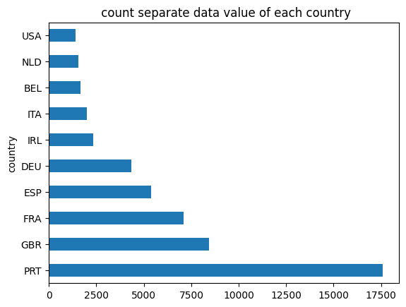

```python
# Top 10 country - Not Interactive plot
plt.title(" count separate data value of each country")
not_cancelled_hotel['country'].value_counts().head(10).plot(kind='barh')
```

```python
df
```

|  | hotel | is_canceled | lead_time | arrival_date_year | arrival_date_month | arrival_date_week_number | arrival_date_day_of_month | stays_in_weekend_nights | stays_in_week_nights | adults | ... | deposit_type | agent | company | days_in_waiting_list | customer_type | adr | required_car_parking_spaces | total_of_special_requests | reservation_status | reservation_status_date |
| --- | --- | --- | --- | --- | --- | --- | --- | --- | --- | --- | --- | --- | --- | --- | --- | --- | --- | --- | --- | --- | --- |
| 0 | Resort Hotel | 0 | 342 | 2015 | July | 27 | 1 | 0 | 0 | 2 | ... | No Deposit | NaN | NaN | 0 | Transient | 0.00 | 0 | 0 | Check-Out | 7/1/2015 |
| 1 | Resort Hotel | 0 | 737 | 2015 | July | 27 | 1 | 0 | 0 | 2 | ... | No Deposit | NaN | NaN | 0 | Transient | 0.00 | 0 | 0 | Check-Out | 7/1/2015 |
| 2 | Resort Hotel | 0 | 7 | 2015 | July | 27 | 1 | 0 | 1 | 1 | ... | No Deposit | NaN | NaN | 0 | Transient | 75.00 | 0 | 0 | Check-Out | 7/2/2015 |
| 3 | Resort Hotel | 0 | 13 | 2015 | July | 27 | 1 | 0 | 1 | 1 | ... | No Deposit | 304.0 | NaN | 0 | Transient | 75.00 | 0 | 0 | Check-Out | 7/2/2015 |
| 4 | Resort Hotel | 0 | 14 | 2015 | July | 27 | 1 | 0 | 2 | 2 | ... | No Deposit | 240.0 | NaN | 0 | Transient | 98.00 | 0 | 1 | Check-Out | 7/3/2015 |
| ... | ... | ... | ... | ... | ... | ... | ... | ... | ... | ... | ... | ... | ... | ... | ... | ... | ... | ... | ... | ... | ... |
| 119385 | City Hotel | 0 | 23 | 2017 | August | 35 | 30 | 2 | 5 | 2 | ... | No Deposit | 394.0 | NaN | 0 | Transient | 96.14 | 0 | 0 | Check-Out | 9/6/2017 |
| 119386 | City Hotel | 0 | 102 | 2017 | August | 35 | 31 | 2 | 5 | 3 | ... | No Deposit | 9.0 | NaN | 0 | Transient | 225.43 | 0 | 2 | Check-Out | 9/7/2017 |
| 119387 | City Hotel | 0 | 34 | 2017 | August | 35 | 31 | 2 | 5 | 2 | ... | No Deposit | 9.0 | NaN | 0 | Transient | 157.71 | 0 | 4 | Check-Out | 9/7/2017 |
| 119388 | City Hotel | 0 | 109 | 2017 | August | 35 | 31 | 2 | 5 | 2 | ... | No Deposit | 89.0 | NaN | 0 | Transient | 104.40 | 0 | 0 | Check-Out | 9/7/2017 |
| 119389 | City Hotel | 0 | 205 | 2017 | August | 35 | 29 | 2 | 7 | 2 | ... | No Deposit | 9.0 | NaN | 0 | Transient | 151.20 | 0 | 2 | Check-Out | 9/7/2017 |

87230 rows × 32 columns